# SecondHalf

```python
import pandas as pd
import numpy as np
import networkx as nx # to work with graphs
import matplotlib.pyplot as plt
file_path = 'task 1 .xlsx'
all_sheets = pd.read_excel(file_path, sheet_name=None)
```

```python
SecondHalf = all_sheets['SecondHalf']
print(SecondHalf)
```

```
        Unnamed: 0  Player 1  Player 2  Player 3 = 13  Player 4  \
0         Player 1         0         5              1         5
1         Player 2         2         0              5         3
2    Player 3 = 13         2         2              0         6
3         Player 4         1         3              4         0
4    Player 6 = 16         0         2              1         1
5         Player 5         0         1              4         1
6    Player 8 = 19         0         2              0         1
7   Player 11 = 17         0         2              1         0
8         Player 7         0         1              2         1
9   Player 10 = 20         0         0              1         0
10   Player 9 = 18         0         1              0         0

    Player 6 = 16  Player 5  Player 8 = 19  Player 11 = 17  Player 7  \
0               3         0              0               1         0
```

[output cut: 23 more lines]

```python
G = nx.DiGraph()
players = SecondHalf.columns[1:]
for i in players:
    G.add_node(i)

for i, row in SecondHalf.iterrows():
    sender = row['Unnamed: 0']  # The player who is passing
    for recipient in players:
        if row[recipient] > 0:
            G.add_edge(sender, recipient, weight=row[recipient])

# Define positions for a 4-3-3 football formation
positions = {
    'Player 1': (0, 0),  # Goalkeeper
    'Player 2': (-2, 1), 'Player 3 = 13': (-1, 1), 'Player 4': (1, 1), 'Player 5': (2, 1),  # Defenders
    'Player 6 = 16': (-1, 2), 'Player 7': (0, 2), 'Player 8 = 19': (1, 2),  # Midfielders
    'Player 9 = 18': (-1, 3), 'Player 10 = 20': (0, 3), 'Player 11 = 17': (1, 3)  # Forwards
}
```

Degree Centrality Analysis

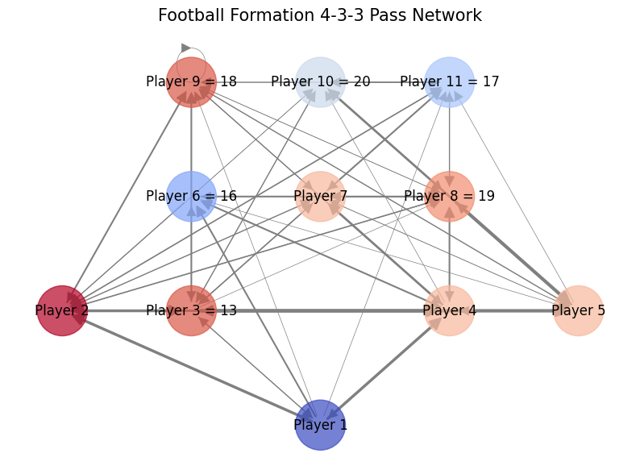

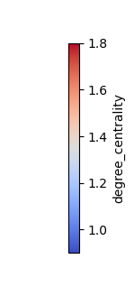

```python
# Calculate Degree Centrality
degree_centrality = nx.degree_centrality(G)

# Normalize centrality values for coloring
norm = plt.Normalize(vmin=min(degree_centrality.values()), vmax=max(degree_centrality.values()))
colors = [degree_centrality[node] for node in G.nodes()]

# Main Plot
plt.figure(figsize=(10, 7))
nx.draw_networkx_nodes(G, positions, node_size=2000, cmap=plt.cm.coolwarm, node_color=colors, alpha=0.7)
nx.draw_networkx_edges(G, positions, edgelist=G.edges(), width=[d['weight']/2 for u, v, d in G.edges(data=True)], arrowstyle='-|>', arrowsize=20, edge_color='gray')
nx.draw_networkx_labels(G, positions, font_size=12, font_family="sans-serif")
plt.title('Football Formation 4-3-3 Pass Network', size=15)
plt.axis('off')
plt.show()

# Colorbar
fig, ax = plt.subplots(figsize=(1, 4))
sm = plt.cm.ScalarMappable(cmap=plt.cm.coolwarm, norm=norm)
sm.set_array([])
cbar = plt.colorbar(sm, ax=ax)
cbar.set_label('degree_centrality')
ax.axis('off')
plt.show()
```

Player 1 (Goalkeeper): Blue color and a low centrality score, indicating few direct connections, which is typical for a goalkeeper.

Player 2 (Defender): Red and a high centrality score, suggesting this player is a key part of the buildup play from the back.

Player 3 = 13 (Defender): Dark Peach, showing good involvement in the passing game.

Player 4 (Defender): Peach, indicating a moderate level of passing connections.

Player 5 (Defender): Peach, likely indicating moderate involvement similar to Player 4.

Player 6 = 16 (Midfielder): Light Blue, which is somewhat involved but not as central as other midfielders.

Player 7 (Midfielder): Peach, suggesting a moderate degree of involvement in the passing game.

Player 8 = 19 (Midfielder): Darker Peach, indicating a significant role in connecting plays and likely one of the team's main playmakers.

Player 9 = 18 (Forward): Dark Peach, showing a high involvement in the attack and passing plays.

Player 10 = 20 (Forward): Light blue, indicating this player is not very central to the team's passing network

Player 11 = 17 (Forward): Light blue, with a level of involvement in passing ever worse than Player 10.

Eigenvectors Centrality Analysis

```python
# We needed to adapt position to the plot to allow a better visualizzation
pos = {
    'Player 1': (0.5, 0.1),  # Goalkeeper
    'Player 2': (0.2, 0.3),  # Left Defender
    'Player 3 = 13': (0.35, 0.3),  # Center Left Defender
    'Player 4': (0.65, 0.3),  # Center Right Defender
    'Player 5': (0.8, 0.3),  # Right Defender
    'Player 6 = 16': (0.3, 0.5),  # Left Midfielder
    'Player 7': (0.5, 0.5),  # Central Midfielder
    'Player 8 = 19': (0.7, 0.5),  # Right Midfielder
    'Player 9 = 18': (0.3, 0.7),  # Left Forward
    'Player 10 = 20': (0.5, 0.7), # Center Forward
    'Player 11 = 17': (0.7, 0.7)  # Right Forward
}
```

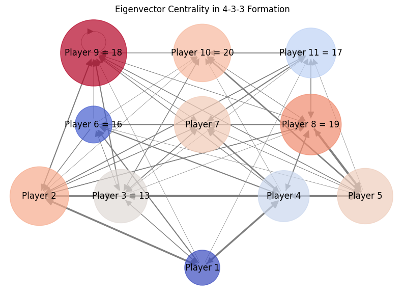

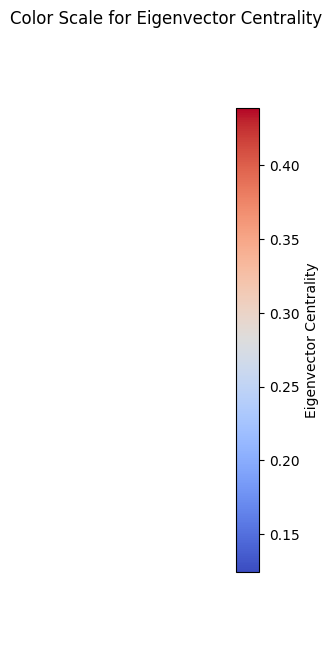

```python
# Calculate the Eigenvector Centrality for each node
eigenvector_centrality = nx.eigenvector_centrality_numpy(G)

# Main plot
plt.figure(figsize=(10, 7))
colors = [eigenvector_centrality[node] for node in G.nodes()]
node_sizes = [20000 * v for v in eigenvector_centrality.values()]
norm = plt.Normalize(vmin=min(eigenvector_centrality.values()), vmax=max(eigenvector_centrality.values()))
nx.draw_networkx_nodes(G, pos, node_size=node_sizes, node_color=colors, cmap=plt.cm.coolwarm, alpha=0.7)
edge_widths = [d['weight'] / 2 for u, v, d in G.edges(data=True)]
nx.draw_networkx_edges(G, pos, edgelist=G.edges(), width=edge_widths, arrowstyle='-|>', arrowsize=20, edge_color='gray')
nx.draw_networkx_labels(G, pos, font_size=12, font_family="sans-serif")
plt.axis('off')
plt.title('Eigenvector Centrality in 4-3-3 Formation')
plt.show()


# Colorbar
fig, ax = plt.subplots(figsize=(2, 8))
sm = plt.cm.ScalarMappable(cmap='coolwarm', norm=norm)
sm.set_array([])
cbar = plt.colorbar(sm, ax=ax, orientation='vertical')
cbar.set_label('Eigenvector Centrality')
ax.axis('off')
plt.title('Color Scale for Eigenvector Centrality')
plt.show()
```

Player 1 (Goalkeeper): Blue with a lower eigenvector centrality, indicating they're a starting point for plays but not a key connector.

Player 2 (Defender): Peach, which suggests a moderate level of influence through connections with other players.

Player 3 = 13 (Defender): Grey, lowly influential in the team’s passing network.

Player 4 (Defender): Light Blue, likely similar in centrality to Player 3, suggesting low influence.

Player 5 (Defender): Peach, indicating moderate influence in passing interactions.

Player 6 = 16 (Midfielder): Dark Blue , showing they have no influence, neither in defensive or transitional play.

Player 7 (Midfielder): Peach, signifying a moderate influence and involvement in the passing network.

Player 8 = 19 (Midfielder): Darker Peach, indicating a stronger influence in the midfield, probably acting as a central hub in the network.

Player 9 = 18 (Forward): Dark Red, showing a high level of influence, possibly due to being a target for key passes in the attacking phase.

Degree Prestige Analysis

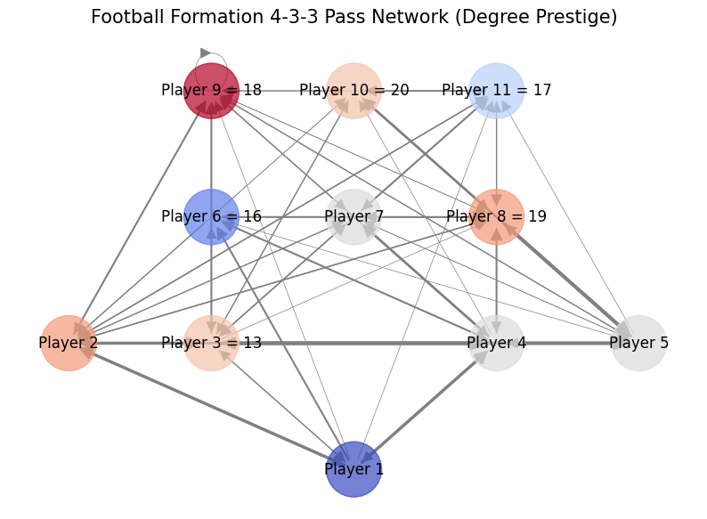

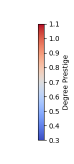

```python
# Calculate Degree Prestige (in-degree centrality)
degree_prestige = nx.in_degree_centrality(G)

# Normalize centrality values for coloring
norm = plt.Normalize(vmin=min(degree_prestige.values()), vmax=max(degree_prestige.values()))
colors = [degree_prestige[node] for node in G.nodes()]

# Main plot
plt.figure(figsize=(10, 7))
nx.draw_networkx_nodes(G, positions, node_size=2000, cmap=plt.cm.coolwarm, node_color=colors, alpha=0.7)
nx.draw_networkx_edges(G, positions, edgelist=G.edges(), width=[d['weight']/2 for u, v, d in G.edges(data=True)], arrowstyle='-|>', arrowsize=20, edge_color='gray')
nx.draw_networkx_labels(G, positions, font_size=12, font_family="sans-serif")
plt.title('Football Formation 4-3-3 Pass Network (Degree Prestige)', size=15)
plt.axis('off')
plt.show()

# Colorbar
fig, ax = plt.subplots(figsize=(1, 4))
sm = plt.cm.ScalarMappable(cmap=plt.cm.coolwarm, norm=norm)
sm.set_array([])
cbar = plt.colorbar(sm, ax=ax)
cbar.set_label('Degree Prestige')
ax.axis('off')
plt.show()
```

Player 1 (Goalkeeper): Blue and low degree prestige, indicating less frequent involvement in passing sequences.

Player 2 (Defender): Peach, suggesting moderate degree prestige, with some involvement in passing to teammates.

Player 3 = 13 (Defender): Peach, indicating moderate involvement.

Player 4 (Defender): Grey, indicating a lowel level of involvement.

Player 6 = 16 (Midfielder): Blue, indicating a lesser role as a pass recipient compared to other players.

Player 7 (Midfielder): Light grey, signifying a medium level of being targeted with passes, quite low for the midfield role.

Player 8 = 19 (Midfielder): Peach, showing a medium-high degree of being targeted, likely reflecting a key playmaking role.

Player 9 = 18 (Forward): Dark Red, indicating a high level of being targeted in the attacking third.

Player 10 = 20 (Forward): Peach, suggesting this player is central to the attacking strategy.

Player 11 = 17 (Forward): Light blue, indicating a non significant involvement in the attack.

PageRank Prestige Analysis

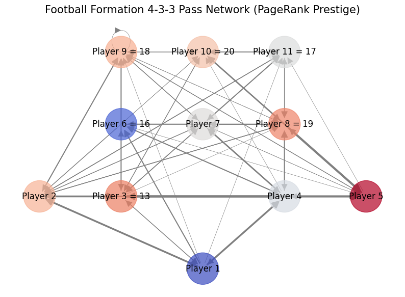

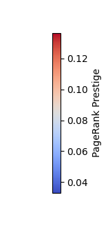

```python
# Calculate PageRank Prestige
pagerank_prestige = nx.pagerank(G, alpha=0.85)  # alpha is the damping factor commonly set to 0.85

# Normalize centrality values for coloring
norm = plt.Normalize(vmin=min(pagerank_prestige.values()), vmax=max(pagerank_prestige.values()))
colors = [pagerank_prestige[node] for node in G.nodes()]

# Main plot
plt.figure(figsize=(10, 7))
nx.draw_networkx_nodes(G, positions, node_size=2000, cmap=plt.cm.coolwarm, node_color=colors, alpha=0.7)
nx.draw_networkx_edges(G, positions, edgelist=G.edges(), width=[d['weight']/2 for u, v, d in G.edges(data=True)], arrowstyle='-|>', arrowsize=20, edge_color='gray')
nx.draw_networkx_labels(G, positions, font_size=12, font_family="sans-serif")
plt.title('Football Formation 4-3-3 Pass Network (PageRank Prestige)', size=15)
plt.axis('off')
plt.show()

# Colorbar
fig, ax = plt.subplots(figsize=(1, 4))
sm = plt.cm.ScalarMappable(cmap=plt.cm.coolwarm, norm=norm)
sm.set_array([])
cbar = plt.colorbar(sm, ax=ax)
cbar.set_label('PageRank Prestige')
ax.axis('off')
plt.show()
```

Player 1 (Goalkeeper): Blue, indicating lower PageRank Prestige, as expected for most goalkeepers.

Player 2 (Defender): Peach, showing a moderate PageRank Prestige, suggesting involvement in passing plays.

Player 3 (Defender): Darker Peach, which shows some influence within the team's network.

Player 4 (Defender): Grey, the color suggests a lower PageRank Prestige than other defenders.

Player 5 (Defender): Red, indicating a high PageRank Prestige, suggesting that this defender plays a key role in passing, likely contributing to both defensive actions and initiating attacks.

Player 6 (Midfielder): Blue, indicating a lower PageRank Prestige among the midfielders, which may suggest a defensive role or less involvement in key passing sequences.

Player 7 (Midfielder): Grey, showing a low-medium level of importance within the network.

Player 8 (Midfielder): Peach, indicating significant influence in the team’s passing network and likely being a key playmaker.

Player 9 (Forward): Peach, suggests a prominent role in the attacking phase, receiving passes from influential players.

Player 10 (Forward): Peach, must be a important component as well of the team's attack

Player 11 (Forward): Light Grey, not quite influential in the network

Macro-level Analysis

```python
# 1. EV Team - Largest eigenvalue of the graph's adjacency matrix
largest_eigenvalue = max(np.linalg.eigvals(nx.adjacency_matrix(G).toarray()).real)
print("Largest Eigenvalue (EV Team):", largest_eigenvalue)

# 2. Density of the Team
density = nx.density(G)
print("Density of the team:", density)

# 3. Clustering Coefficient
# For directed graphs, it's often useful to consider the graph as undirected for clustering calculations
clustering_coefficient = nx.average_clustering(G.to_undirected())
print("Clustering Coefficient:", clustering_coefficient)
```

```
Largest Eigenvalue (EV Team): 15.017662818355479
Density of the team: 0.7181818181818181
Clustering Coefficient: 0.8758297258297258
```

The metric are similar to the First Half, maybe slightly lower. It suggests that the team maintained a consistent level of play throughout the match. Despite the substitutions, the structural integrity of the team's passing network wasn't significantly altered.

Stable Largest Eigenvalue:

The team's connectivity remained strong, indicating that the substitutes integrated well and maintained the flow of the game established by the starting players.

Slightly Lower Density:

A slight decrease in density might indicate that the team was not passing quite as much or that the players were not as closely connected as in the first half. This could be due to fatigue, tactical changes, or the natural flow of the game as the team adapts to the scoreline, opponents, or other conditions.

High Clustering Coefficient:

Continuing to have a high clustering coefficient suggests that even with substitutions, the team's players kept supporting each other with multiple passing options. It reflects well on the team's depth and the effectiveness of the substitutes, who were likely well-prepared to fit into the existing tactical setup.

```python
Metrics_Second_Half = all_sheets['Metrics_Second_Half']
Metrics_Second_Half = Metrics_Second_Half.drop('Nome', axis=1)
Metrics_Second_Half['N°'] = Metrics_Second_Half['N°'].apply(lambda x: 'Player ' + str(x)) # I had to add as prefix the string player to allow pandas to read the df correctly
print(Metrics_Second_Half)
```

[output not shown]

Second Half Metric Table

```python
Metrics_Second_Half['Degree centrality'] = Metrics_Second_Half['N°'].map(degree_centrality)
Metrics_Second_Half['degree prestige'] = Metrics_Second_Half['N°'].map(degree_prestige)
Metrics_Second_Half['page rank'] = Metrics_Second_Half['N°'].map(pagerank_prestige)
Metrics_Second_Half['eigen vector'] = Metrics_Second_Half['N°'].map(eigenvector_centrality)
#Since from now on this metrics are single values representative of the entire Network, and not specific to each player, for simplicity we are just gonna assign the same value to each row of the df
Metrics_Second_Half['EV team'] = largest_eigenvalue
Metrics_Second_Half['density of the team'] = density
Metrics_Second_Half['clustering coefficient'] = clustering_coefficient

Metrics_Second_Half
```

[output not shown]